# Introduction to probability

# Multi-dimensional distributions

## Joint probability distribution

- $f(x,y)\geq0$
- $\sum_{x,y}f(x,y)=1$

independence: $f(x,y)=g(x)*h(y)$.

## Marginal probability density functions

$$ g(x) = \int dy f(x,y), \\ h(y)=\int dx f(x,y) $$

## Conditional probability distribution

$$ g(x|y)=\dfrac{f(x,y)}{h(y)} $$

- mean: $E[x|y]=\int x g(x|y) dx$
- variance: $V[x|y]=E[(x-E[x|y])^2|y]$

## Contigency table

A contingency table summarizes information of multiple discrete random variables

### Bayesian theorem

The *posterior probability* ${\rm Pr}(x|y)$ of $x$ is calculated by $$ {\rm Pr}(x|y)=\dfrac{{\rm Pr}(y|x)*{\rm Pr}(x)}{{\rm Pr}(y)} =\dfrac{{\rm Pr}(y|x)*{\rm Pr}(x)}{{\rm Pr}(y|x){\rm Pr}(x) +{\rm Pr}(y|\bar x){\rm Pr}(\bar x)} $$ where ${\rm Pr}(x)$ is called *prior probability* of $x$, the probability of cause $x$ before effect $y$ is known.

### Covariance and correlation

$$ V[x+y]=V[x]+V[y]+2{\rm cov}[x,y] $$ where ${\rm cov}[x,y]$ is the covariance of $x$ and $y$ $$ {\rm cov}[x,y] = E[x-E[x]]* E[y-E[y]] $$

- positively correlated: ${\rm cov}[x,y]>0$
- negatively correlated: ${\rm cov}[x,y]<0$
- uncorrelated: ${\rm cov}[x,y]\sim 0$

Generally, assuming $$\mathbf{X}=(X_1, X_2, ... , X_n)^{\mathrm T}$$ are random variables, each with finite variance, then the **variance–covariance matrix** $\operatorname{K}_{\mathbf{X}\mathbf{X}}$ is the matrix whose $(i,j)$ entry is the covariance:

$$ \operatorname{K}_{X_i X_j} = \operatorname{cov}[X_i, X_j] = \operatorname{E}[(X_i - \operatorname{E}[X_i])(X_j - \operatorname{E}[X_j])] $$ where the operator $\operatorname{E}$ denotes the expected value (mean) of its argument.

For $$\operatorname{K}_{\mathbf{X}\mathbf{X}}=\operatorname{V}(\mathbf{X}) = \operatorname{E} \left[ \left( \mathbf{X} - \operatorname{E}[\mathbf{X}] \right) \left( \mathbf{X} - \operatorname{E}[\mathbf{X}] \right)^{\rm T} \right]$$

and $\mathbf{\mu_X} = \operatorname{E}$(\textbf{X}), where $\mathbf{X} = (X_1,\ldots,X_n)$ is a $n$-dimensional random variable, the following basic properties apply

$$\operatorname{K}_{\mathbf{X}\mathbf{X}} = \operatorname{E}(\mathbf{X X^{\rm T}}) - \mathbf{\mu_X}\mathbf{\mu_X}^{\rm T} $$

The correlation coeffcient $\rho_{x,y}$ between $x$ and $y$, $$ \rho_{x,y}=\rho=\dfrac{K_{xy}}{\sqrt{K_{xx}}\cdot \sqrt{K_{yy}}}=\dfrac{K_{xy}}{D[x]\cdot D[y]} $$

## Non-independent variables

It may be the case that variables are correlated (not independent).

Suppose one constructs an order-$n$ Gaussian vector out of random variables $(x_1,\ldots,x_n)$, where each variable has means given by $(\mu_1, \ldots, \mu_n)$. Let the covariance matrix be denoted by $\mathit\Sigma$.

The joint probability density function of these $n$ random variables is then given by:

$$ f(x_1,\ldots,x_n)=\frac{1}{(2\pi)^{n/2}\sqrt{\text{det}(\mathit\Sigma)}} \exp\left( -\frac{1}{2} \left[x_1-\mu_1,\ldots,x_n-\mu_n\right]\mathit\Sigma^{-1}\left[x_1-\mu_1,\ldots,x_n-\mu_n\right]^\mathrm{T} \right) $$

- In the two variable case, $$ \mathit\Sigma^{-1} = \dfrac{1}{\text{det}(\mathit\Sigma)} \begin{bmatrix} K_{\mathit{XX}} & K_{\mathit{XY}} \\ K_{\mathit{YX}} & K_{\mathit{YY}} \end{bmatrix} = \dfrac{1}{\text{det}(\mathit\Sigma)} \begin{bmatrix} \sigma^2_x & \operatorname{cov}(X,Y) \\ \operatorname{cov}(X,Y) & \sigma^2_y \end{bmatrix} $$ where $\operatorname{cov}(X,Y)=\rho \sigma_x\sigma_y$ and $\dfrac{1}{\text{det}(\mathit\Sigma)}=\sigma^2_x\sigma^2_y(1-\rho^2)$. The joint probability density function is given by: $$f(x,y) = \frac{1}{2\pi \sigma_x \sigma_y \sqrt{1-\rho^2}} \exp\left[ -\frac{1}{2(1-\rho^2)} \left(\frac{(x-\mu_x)^2}{\sigma_x^2} - \frac{2\rho(x-\mu_x)(y-\mu_y)}{\sigma_x\sigma_y} + \frac{(y-\mu_y)^2}{\sigma_y^2}\right) \right] $$

If the correlation coefficient $\rho=0$, the two variables become independent $$ f(x,y) = \frac{1}{2\pi \sigma_x \sigma_y} \exp\left[ -\frac{1}{2} \left(\frac{(x-\mu_x)^2}{\sigma_x^2} + \frac{(y-\mu_y)^2}{\sigma_y^2}\right) \right] =f(x)*f(y) $$

## An example: $d$-sided dice

with the probability of obtaining each side $\mathbf{p} = (p_1, \cdots, p_d )^T$,

- $0\leq p_i \leq1$.
- $\sum^d_i p_i=1$

Let $\mathbf{x} = (x^{(1)},\cdots, x^{(d)})^T$ be the number of times each side appears when the dice is thrown $n$ times, where

$$ \sum_i x^{(i)} = n. $$ The probability distribution that $x$ follows is the multinomial distribution and is denoted by **Mult(n, p)**

$$ f(\mathbf{x}) =\dfrac{n!}{x^{(1)}! x^{(2)}!\cdots x^{(d)!}} p^{x^{(1)}}_1p^{x^{(2)}}_2\cdots p^{x^{(d)}}_d $$

When $d = 2$, **Mult(n, p)** is reduced to **Bi(n, $p_1$)**.

normalization: $$ \sum_{\mathbf{x}} f(\mathbf{x}) = (p_1+p_2+\cdots p_d)^n = 1. $$

moment-generating function of **Mult(n, p)**: $$ M_{\mathbf{x}}(t) = E[e^{\mathbf{t}^T\mathbf{x}}]=\sum_{\mathbf{x}} f(\mathbf{x})e^{\mathbf{t}^T\mathbf{x}} =(p_1 e^{t_1}+p_2e^{t_2}+\cdots+p_de^{t_d})^n. $$

- Mean: $E[x^{(j)}]=np_j$
- Covariance:

$$ {\rm Cov}[x^{(i)}, x^{(j)}] =\begin{cases} np_i(1-p_i), & i=j \\ -np_ip_j, & i\neq j \end{cases} $$

# Rolling dice twice

The random variable $X$ is the sum of two values of 1-6. Thus, the random variable $X$ takes the value of: 2,3,4,...,12 with the probability $(1/6)^2, 2\times (1/6)^2, 3\times (1/6)^2, ..., \times (1/6)^2$.

- The mean value is given by

\begin{align} E[X] &= 2\times (1/36) + 3\times (2/36) + 4\times (3/36) + 5\times (4/36) + 6\times (5/36) \nonumber\\ &+ 7\times (6/36) + 8\times (5/36)+ 9\times (4/36)+ 10\times (3/36)+ 11\times (2/36) + 12\times (1/36) \nonumber\\ &=7. \end{align}

Or it can be calculated simply with $E[X]= 2\times [1+2+3+\cdots+6]/6=2\times (1+6)\times6/2/6=7$.

- The variance is given by

$$ \sigma^2 = \sum_i (X_i-E[X])^2 \times p_i. $$ Note: $p_i$, instead of $1/N$ is used here because the probability $p_i$ of each $X_i$ is different.

```python
X_dist = pd.DataFrame(index=[2,3,4,5,6,7,8,9,10,11,12])
X_dist['prob'] = [1,2,3,4,5,6,5,4,3,2,1]
X_dist['prob']=X_dist['prob']/36
```

```python
X_dist
```

|  | prob |
| --- | --- |
| 2 | 0.027778 |
| 3 | 0.055556 |
| 4 | 0.083333 |
| 5 | 0.111111 |
| 6 | 0.138889 |
| 7 | 0.166667 |
| 8 | 0.138889 |
| 9 | 0.111111 |
| 10 | 0.083333 |
| 11 | 0.055556 |
| 12 | 0.027778 |

**compute the population mean and population variance**

```python
mean = pd.Series(X_dist.index*X_dist.prob).sum()
variance = pd.Series((X_dist.index-mean)**2*X_dist.prob).sum()
mean,variance
```

```
(6.999999999999998, 5.833333333333333)
```

**Sampling 5000 times which generates 5000 samples**

```python
import pandas as pd

die = pd.DataFrame([1, 2, 3, 4, 5, 6])
trial = 5000

results = [die.sample(2, replace=True).sum().loc[0] for i in range(trial)]
```

```python
results[:10]
```

```
[7, 7, 4, 4, 9, 5, 5, 6, 12, 6]
```

**compute the sample mean and sample variance** using the methods of pd.Series():

.mean() and .var()

```python
pd.Series(results).mean(), pd.Series(results).var()
```

```
(7.041, 5.804079815963295)
```

```python
freq = pd.DataFrame(results)[0].value_counts()
sort_result=freq.sort_index()
sort_result
```

```
2     129
3     268
4     429
5     551
6     670
7     812
8     703
9     569
10    458
11    289
12    122
Name: 0, dtype: int64
```

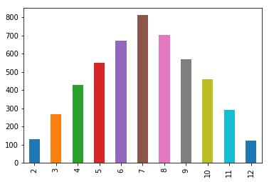

```python
sort_result.plot(kind='bar')
```